# 第二章 获取文本语料和词汇资源

### 本章目的

哪些是有用的文本语料和词汇资源，怎么使用Python获得？

哪些Python结构对于这项工作最有用？

我们写Python代码时怎么避免重复

### 本章内容

获取文本语料库

条件频率分布

更多关于Python：代码重用

词典资源

WordNet

```python
%matplotlib inline
```

## 获取文本语料库

### 古腾堡语料库

谷腾堡项目: 大约50,000本免费电子图书

http://www.gutenberg.org

```python
import nltk
from nltk.corpus import gutenberg
gutenberg.fileids()
```

```
['austen-emma.txt',
 'austen-persuasion.txt',
 'austen-sense.txt',
 'bible-kjv.txt',
 'blake-poems.txt',
 'bryant-stories.txt',
 'burgess-busterbrown.txt',
 'carroll-alice.txt',
 'chesterton-ball.txt',
 'chesterton-brown.txt',
 'chesterton-thursday.txt',
 'edgeworth-parents.txt',
 'melville-moby_dick.txt',
 'milton-paradise.txt',
 'shakespeare-caesar.txt',
 'shakespeare-hamlet.txt',
 'shakespeare-macbeth.txt',
 'whitman-leaves.txt']
```

```python
emma = nltk.corpus.gutenberg.words('austen-emma.txt')
len(emma)
```

```
192427
```

```python
macbeth_sentences = gutenberg.sents('shakespeare-macbeth.txt')
macbeth_sentences
```

```
[['[', 'The', 'Tragedie', 'of', 'Macbeth', 'by', 'William', 'Shakespeare', '1603', ']'], ['Actus', 'Primus', '.'], ...]
```

```python
longest_len = max(len(s) for s in macbeth_sentences)
[s for s in macbeth_sentences if len(s) == longest_len]
```

```
[['Doubtfull',
  'it',
  'stood',
  ',',
  'As',
  'two',
  'spent',
  'Swimmers',
  ',',
  'that',
  'doe',
  'cling',
  'together',
  ',',
  'And',
  'choake',
  'their',
  'Art',
  ':',
  'The',
  'mercilesse',
  'Macdonwald',
  '(',
  'Worthie',
  'to',
  'be',
  'a',
  'Rebell',
  ',',
  'for',
  'to',
  'that',
  'The',
  'multiplying',
  'Villanies',
  'of',
  'Nature',
  'Doe',
  'swarme',
  'vpon',
```

[output cut: 103 more lines]

```
  'the',
  'Naue',
  'toth',
  "'",
  'Chops',
  ',',
  'And',
  'fix',
  "'",
  'd',
  'his',
  'Head',
  'vpon',
  'our',
  'Battlements']]
```

```python
for fileid in gutenberg.fileids():
    num_chars = len(gutenberg.raw(fileid))
    num_words = len(gutenberg.words(fileid))
    num_sents = len(gutenberg.sents(fileid))
    num_vocab = len(set(w.lower() for w in gutenberg.words(fileid)))
    print(round(num_chars/num_words), round(num_words/num_sents), round(num_words/num_vocab), fileid)
```

```
5 25 26 austen-emma.txt
5 26 17 austen-persuasion.txt
5 28 22 austen-sense.txt
4 34 79 bible-kjv.txt
5 19 5 blake-poems.txt
4 19 14 bryant-stories.txt
4 18 12 burgess-busterbrown.txt
4 20 13 carroll-alice.txt
5 20 12 chesterton-ball.txt
5 23 11 chesterton-brown.txt
5 18 11 chesterton-thursday.txt
4 21 25 edgeworth-parents.txt
5 26 15 melville-moby_dick.txt
5 52 11 milton-paradise.txt
4 12 9 shakespeare-caesar.txt
4 12 8 shakespeare-hamlet.txt
4 12 7 shakespeare-macbeth.txt
5 36 12 whitman-leaves.txt
```

### 网络和聊天文本

NLTK的网络文本小集合内容包括Firefox交流论坛，《加勒比海盗》的电影剧本，个人广告和葡萄酒的评论等

```python
from nltk.corpus import webtext
for fileid in webtext.fileids():
    print(fileid, webtext.raw(fileid)[:65], '...')
```

```
firefox.txt Cookie Manager: "Don't allow sites that set removed cookies to se ...
grail.txt SCENE 1: [wind] [clop clop clop]
KING ARTHUR: Whoa there!  [clop ...
overheard.txt White guy: So, do you have any plans for this evening?
Asian girl ...
pirates.txt PIRATES OF THE CARRIBEAN: DEAD MAN'S CHEST, by Ted Elliott & Terr ...
singles.txt 25 SEXY MALE, seeks attrac older single lady, for discreet encoun ...
wine.txt Lovely delicate, fragrant Rhone wine. Polished leather and strawb ...
```

即时消息聊天会话语料库，最初由美国海军学院为研究自动检测互联网虐童而收集的

```python
from nltk.corpus import nps_chat
chatroom = nps_chat.posts('10-19-20s_706posts.xml')
chatroom[123]
```

```
['i',
 'do',
 "n't",
 'want',
 'hot',
 'pics',
 'of',
 'a',
 'female',
 ',',
 'I',
 'can',
 'look',
 'in',
 'a',
 'mirror',
 '.']
```

### 布朗语料库

布朗语料库是第一个百万词级的英语电子语料库，由布朗大学于1961 年创建

[figure not shown]

```python
from nltk.corpus import brown
brown.categories()
```

```
['adventure',
 'belles_lettres',
 'editorial',
 'fiction',
 'government',
 'hobbies',
 'humor',
 'learned',
 'lore',
 'mystery',
 'news',
 'religion',
 'reviews',
 'romance',
 'science_fiction']
```

```python
brown.words(categories='news')
```

```
['The', 'Fulton', 'County', 'Grand', 'Jury', 'said', ...]
```

```python
brown.words(fileids=['cg22'])
```

```
['Does', 'our', 'society', 'have', 'a', 'runaway', ',', ...]
```

```python
brown.sents(categories=['news', 'editorial', 'reviews'])
```

```
[['The', 'Fulton', 'County', 'Grand', 'Jury', 'said', 'Friday', 'an', 'investigation', 'of', "Atlanta's", 'recent', 'primary', 'election', 'produced', '``', 'no', 'evidence', "''", 'that', 'any', 'irregularities', 'took', 'place', '.'], ['The', 'jury', 'further', 'said', 'in', 'term-end', 'presentme…
```

```python
from nltk.corpus import brown
news_text = brown.words(categories='news')
fdist = nltk.FreqDist(w.lower() for w in news_text)
modals = ['can', 'could', 'may', 'might', 'must', 'will']
for m in modals:
    print(m + ':', fdist[m], end=' ')
```

```
can: 94 could: 87 may: 93 might: 38 must: 53 will: 389
```

```python
cfd = nltk.ConditionalFreqDist((genre, word)for genre in brown.categories()for word in brown.words(categories=genre))
genres = ['news', 'religion', 'hobbies', 'science_fiction', 'romance', 'humor']
modals = ['can', 'could', 'may', 'might', 'must', 'will']
cfd.tabulate(conditions=genres, samples=modals)
```

```
                  can could   may might  must  will
           news    93    86    66    38    50   389
       religion    82    59    78    12    54    71
        hobbies   268    58   131    22    83   264
science_fiction    16    49     4    12     8    16
        romance    74   193    11    51    45    43
          humor    16    30     8     8     9    13
```

### 路透社语料库

路透社语料库包含10,788 个新闻文档，共计130 万字。这些文档分成90 个主题，按照“训练”和“测试”分为两组

```python
from nltk.corpus import reuters
reuters.fileids()
```

```
['test/14826',
 'test/14828',
 'test/14829',
 'test/14832',
 'test/14833',
 'test/14839',
 'test/14840',
 'test/14841',
 'test/14842',
 'test/14843',
 'test/14844',
 'test/14849',
 'test/14852',
 'test/14854',
 'test/14858',
 'test/14859',
 'test/14860',
 'test/14861',
 'test/14862',
 'test/14863',
 'test/14865',
 'test/14867',
 'test/14872',
 'test/14873',
 'test/14875',
 'test/14876',
 'test/14877',
 'test/14881',
 'test/14882',
 'test/14885',
 'test/14886',
 'test/14888',
 'test/14890',
 'test/14891',
 'test/14892',
 'test/14899',
 'test/14900',
 'test/14903',
 'test/14904',
 'test/14907',
```

[output cut: 946 more lines]

```
 'test/16568',
 'test/16569',
 'test/16570',
 'test/16574',
 'test/16577',
 'test/16581',
 'test/16583',
 'test/16584',
 'test/16585',
 'test/16587',
 'test/16588',
 'test/16589',
 'test/16590',
 'test/16591',
 ...]
```

```python
reuters.fileids(['barley', 'corn'])
```

```
['test/14832',
 'test/14858',
 'test/15033',
 'test/15043',
 'test/15106',
 'test/15287',
 'test/15341',
 'test/15618',
 'test/15648',
 'test/15649',
 'test/15676',
 'test/15686',
 'test/15720',
 'test/15728',
 'test/15845',
 'test/15856',
 'test/15860',
 'test/15863',
 'test/15871',
 'test/15875',
 'test/15877',
 'test/15890',
 'test/15904',
 'test/15906',
 'test/15910',
 'test/15911',
 'test/15917',
 'test/15952',
 'test/15999',
 'test/16012',
 'test/16071',
 'test/16099',
 'test/16147',
 'test/16525',
 'test/16624',
 'test/16751',
 'test/16765',
 'test/17503',
 'test/17509',
 'test/17722',
```

[output cut: 209 more lines]

```
 'training/8759',
 'training/8941',
 'training/8983',
 'training/8993',
 'training/9058',
 'training/9093',
 'training/9094',
 'training/934',
 'training/9470',
 'training/9521',
 'training/9667',
 'training/97',
 'training/9865',
 'training/9958',
 'training/9989']
```

```python
reuters.words(['training/9865', 'training/9880'])
```

```
['FRENCH', 'FREE', 'MARKET', 'CEREAL', 'EXPORT', ...]
```

```python
reuters.words('training/9865')[:14]
```

```
['FRENCH',
 'FREE',
 'MARKET',
 'CEREAL',
 'EXPORT',
 'BIDS',
 'DETAILED',
 'French',
 'operators',
 'have',
 'requested',
 'licences',
 'to',
 'export']
```

```python
reuters.words(categories=['barley', 'corn'])
```

```
['THAI', 'TRADE', 'DEFICIT', 'WIDENS', 'IN', 'FIRST', ...]
```

```python
reuters.categories('training/9865')
```

```
['barley', 'corn', 'grain', 'wheat']
```

### 美国总统就职演说语料库

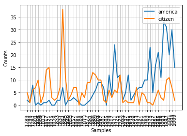

```python
from nltk.corpus import inaugural
cfd = nltk.ConditionalFreqDist((target, fileid[:4])
                               for fileid in inaugural.fileids()
                               for w in inaugural.words(fileid)
                               for target in ['america', 'citizen']
                               if w.lower().startswith(target))
cfd.plot()
```

### 标注文本语料库

许多文本语料库都包含语言学标记，如词性标记、命名实体、句法结构、语义角色等

[figure not shown]

### 其他语言的语料库

```python
nltk.corpus.cess_esp.words()
```

```
['El', 'grupo', 'estatal', 'Electricité_de_France', ...]
```

```python
nltk.corpus.indian.words('hindi.pos')
```

```
['पूर्ण', 'प्रतिबंध', 'हटाओ', ':', 'इराक', 'संयुक्त', ...]
```

```python
nltk.corpus.floresta.words()
```

```
['Um', 'revivalismo', 'refrescante', 'O', '7_e_Meio', ...]
```

```python
nltk.corpus.udhr.fileids()
```

```
['Abkhaz-Cyrillic+Abkh',
 'Abkhaz-UTF8',
 'Achehnese-Latin1',
 'Achuar-Shiwiar-Latin1',
 'Adja-UTF8',
 'Afaan_Oromo_Oromiffa-Latin1',
 'Afrikaans-Latin1',
 'Aguaruna-Latin1',
 'Akuapem_Twi-UTF8',
 'Albanian_Shqip-Latin1',
 'Amahuaca',
 'Amahuaca-Latin1',
 'Amarakaeri-Latin1',
 'Amuesha-Yanesha-UTF8',
 'Arabela-Latin1',
 'Arabic_Alarabia-Arabic',
 'Asante-UTF8',
 'Ashaninca-Latin1',
 'Asheninca-Latin1',
 'Asturian_Bable-Latin1',
 'Aymara-Latin1',
 'Balinese-Latin1',
 'Bambara-UTF8',
 'Baoule-UTF8',
 'Basque_Euskara-Latin1',
 'Batonu_Bariba-UTF8',
 'Belorus_Belaruski-Cyrillic',
 'Belorus_Belaruski-UTF8',
 'Bemba-Latin1',
 'Bengali-UTF8',
 'Beti-UTF8',
 'Bichelamar-Latin1',
 'Bikol_Bicolano-Latin1',
 'Bora-Latin1',
 'Bosnian_Bosanski-Cyrillic',
 'Bosnian_Bosanski-Latin2',
 'Bosnian_Bosanski-UTF8',
 'Breton-Latin1',
 'Bugisnese-Latin1',
 'Bulgarian_Balgarski-Cyrillic',
```

[output cut: 255 more lines]

```
 'Wama-UTF8',
 'Waray-Latin1',
 'Wayuu-Latin1',
 'Welsh_Cymraeg-Latin1',
 'WesternSotho_Tswana-Setswana-Latin1',
 'Wolof-Latin1',
 'Xhosa-Latin1',
 'Yagua-Latin1',
 'Yao-Latin1',
 'Yapese-Latin1',
 'Yoruba-UTF8',
 'Zapoteco-Latin1',
 'Zapoteco-SanLucasQuiavini-Latin1',
 'Zhuang-Latin1',
 'Zulu-Latin1']
```

```python
nltk.corpus.udhr.words('Chinese_Mandarin-GB2312')[11:]
```

```
['日', '，', '联', '合', '国', '大', '会', '通', '过', '并', '颁', ...]
```

```python
nltk.corpus.udhr.words('Japanese_Nihongo-UTF8')[11:]
```

```
['〈', '前文', '〉', ...]
```

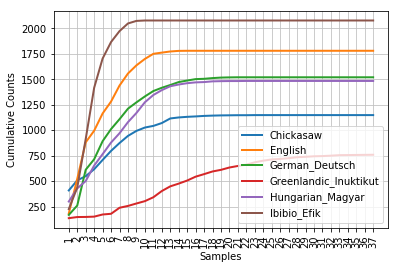

```python
from nltk.corpus import udhr
languages = ['Chickasaw', 'English', 'German_Deutsch','Greenlandic_Inuktikut', 'Hungarian_Magyar', 'Ibibio_Efik']
cfd = nltk.ConditionalFreqDist((lang, len(word))
                               for lang in languages
                               for word in udhr.words(lang + '-Latin1'))
cfd.plot(cumulative=True)
```

## 文本语料库的结构

[figure not shown]

```python
raw = gutenberg.raw("burgess-busterbrown.txt")
raw[1:20]
```

```
'The Adventures of B'
```

```python
words = gutenberg.words("burgess-busterbrown.txt")
words[1:5]
```

```
['The', 'Adventures', 'of', 'Buster']
```

```python
sents = gutenberg.sents("burgess-busterbrown.txt")
sents[1:3]
```

```
[['I'], ['BUSTER', 'BEAR', 'GOES', 'FISHING']]
```

## 载入你自己的语料库

读取自己收集的文本文件

```python
from nltk.corpus import PlaintextCorpusReader
corpus_root = '/usr/share/dict'
wordlists = PlaintextCorpusReader(corpus_root, '.*')
wordlists.fileids()
```

```
['README', 'connectives', 'propernames', 'web2', 'web2a', 'words']
```

```python
wordlists.words('connectives')
```

```
['the', 'of', 'and', 'to', 'a', 'in', 'that', 'is', ...]
```

## 条件频率分布

### 条件和事件

**频率分布**计算观察到的事件，如文本中出现的词汇

text = [‘The’, ‘Fulton’, ‘County’, ‘Grand’, ‘Jury’, ‘said’, …]

**条件频率**分布需要给每个事件关联一个条件，以处理pair序列

pairs = [(‘news’, ‘The’), (‘news’, ‘Fulton’), (‘news’, ‘County’), (‘news’, ‘Grand’), (‘news’, ‘Jury’), (‘news’, ‘said’), …]

[figure not shown]

### 按文体计数词汇

FreqDist()以列表作为输入

ConditionalFreqDist()以pair列表作为输入

```python
from nltk.corpus import brown
cfd = nltk.ConditionalFreqDist((genre, word)
                               for genre in brown.categories()
                               for word in brown.words(categories=genre))
genre_word = [(genre, word)
              for genre in ['news', 'romance']
              for word in brown.words(categories=genre)]
len(genre_word)
```

```
170576
```

```python
genre_word[:4]
```

```
[('news', 'The'), ('news', 'Fulton'), ('news', 'County'), ('news', 'Grand')]
```

```python
genre_word[-4:]
```

```
[('romance', 'afraid'),
 ('romance', 'not'),
 ('romance', "''"),
 ('romance', '.')]
```

```python
cfd = nltk.ConditionalFreqDist(genre_word)
cfd
```

```
ConditionalFreqDist(nltk.probability.FreqDist,
                    {'news': FreqDist({'The': 806,
                               'Fulton': 14,
                               'County': 35,
                               'Grand': 6,
                               'Jury': 2,
                               'said': 402,
                               'Friday': 41,
                               'an': 300,
                               'investigation': 9,
                               'of': 2849,
                               "Atlanta's": 4,
                               'recent': 20,
                               'primary': 17,
                               'election': 38,
                               'produced': 6,
                               '``': 732,
                               'no': 109,
                               'evidence': 17,
                               "''": 702,
                               'that': 802,
                               'any': 90,
                               'irregularities': 3,
                               'took': 47,
                               'place': 25,
                               '.': 4030,
                               'jury': 44,
                               'further': 16,
                               'in': 1893,
                               'term-end': 1,
                               'presentments': 1,
                               'the': 5580,
                               'City': 44,
                               'Executive': 6,
                               'Committee': 37,
                               ',': 5188,
                               'which': 244,
                               'had': 279,
                               'over-all': 2,
                               'charge': 17,
```

[output cut: 1948 more lines]

```
                               'ironed': 1,
                               'Evadna': 3,
                               'Mae': 3,
                               'Evans': 8,
                               'flannel': 2,
                               'wrapper': 1,
                               'until': 34,
                               'nine': 4,
                               'got': 89,
                               "Best's": 1,
                               'Liliputian': 1,
                               'Bazaar': 1,
                               'New': 15,
                               'York': 13,
                               ...})})
```

```python
cfd.conditions()
```

```
['news', 'romance']
```

```python
print(cfd['news'])
```

```
<FreqDist with 14394 samples and 100554 outcomes>
```

```python
cfd['romance'].most_common(10)
```

```
[(',', 3899),
 ('.', 3736),
 ('the', 2758),
 ('and', 1776),
 ('to', 1502),
 ('a', 1335),
 ('of', 1186),
 ('``', 1045),
 ("''", 1044),
 ('was', 993)]
```

```python
cfd['romance']['could']
```

```
193
```

### 绘制分布图和分布表

```python
from nltk.corpus import udhr
languages = ['Chickasaw', 'English', 'German_Deutsch','Greenlandic_Inuktikut', 'Hungarian_Magyar', 'Ibibio_Efik']
cfd = nltk.ConditionalFreqDist((lang, len(word))
                               for lang in languages
                               for word in udhr.words(lang + '-Latin1'))
cfd.tabulate(conditions=['English', 'German_Deutsch'],samples=range(20), cumulative=False)
```

```
                 0   1   2   3   4   5   6   7   8   9  10  11  12  13  14  15  16  17  18  19
       English   0 185 340 358 114 169 117 157 118  80  63  50  12  11   6   1   0   0   0   0
German_Deutsch   0 171  92 351 103 177 119  97 103  62  58  53  32  27  29  15  14   3   7   5
```

### 使用二元模式生成随机文本

创建二元模式(bigrams)

```python
sent = ['In', 'the', 'beginning', 'God', 'created', 'the', 'heaven','and', 'the', 'earth', '.']
list(nltk.bigrams(sent))
```

```
[('In', 'the'),
 ('the', 'beginning'),
 ('beginning', 'God'),
 ('God', 'created'),
 ('created', 'the'),
 ('the', 'heaven'),
 ('heaven', 'and'),
 ('and', 'the'),
 ('the', 'earth'),
 ('earth', '.')]
```

获得《创世记》文本中所有的bigrams

构造条件频率分布来记录哪些词汇最有可能跟在给定词的后面，从而生成随机文本

```python
def generate_model(cfdist, word, num=15):
    for i in range(num):
        print(word, end=' ')
        word = cfdist[word].max()
text = nltk.corpus.genesis.words('english-kjv.txt')
bigrams = nltk.bigrams(text)
cfd = nltk.ConditionalFreqDist(bigrams)
cfd['living']
```

```
FreqDist({',': 1,
          '.': 1,
          'creature': 7,
          'soul': 1,
          'substance': 2,
          'thing': 4})
```

```python
generate_model(cfd, 'living')
```

```
living creature that he said , and the land of the land of the land
```

是否真的随机？如何改进？

条件频率分布用法

[figure not shown]

## 更多关于Python：代码重用

### 函数

函数是命名的代码块，执行一些明确的任务

函数通常使用称为参数的变量来接受输入

函数可能会产生结果，称为返回值

使用关键字def 加函数名以及所有输入参数来定义函数，接下来是函数的主体

```python
def plural(word):
    if word.endswith('y'):
        return word[:-1] + 'ies'
    elif word[-1] in 'sx' or word[-2:] in ['sh', 'ch']:
        return word + 'es'
    elif word.endswith('an'):
        return word[:-2] + 'en'
    else:
        return word + 's'
plural('fairy')
```

```
'fairies'
```

## 词典资源

词典或者词典资源是词(短语)以及一些相关信息的集合，例如词性和词义等

[figure not shown]

### 词汇语料库（Unix：/usr/dict/words）

被拼写检查程序使用

利用词汇语料库发现不常用或者错拼的词语

```python
def unusual_words(text):
    text_vocab = set(w.lower() for w in text if w.isalpha())
    english_vocab = set(w.lower() for w in nltk.corpus.words.words())
    unusual = text_vocab - english_vocab
    return sorted(unusual)
unusual_words(nltk.corpus.gutenberg.words('austen-sense.txt'))
```

```
['abbeyland',
 'abhorred',
 'abilities',
 'abounded',
 'abridgement',
 'abused',
 'abuses',
 'accents',
 'accepting',
 'accommodations',
 'accompanied',
 'accounted',
 'accounts',
 'accustomary',
 'aches',
 'acknowledging',
 'acknowledgment',
 'acknowledgments',
 'acquaintances',
 'acquiesced',
 'acquitted',
 'acquitting',
 'acted',
 'actions',
 'adapted',
 'adding',
 'additions',
 'addressed',
 'addresses',
 'addressing',
 'adhering',
 'adieus',
 'adjusting',
 'administering',
 'admirers',
 'admires',
 'admitting',
 'adorned',
 'advances',
 'advantages',
```

[output cut: 946 more lines]

```
 'oldest',
 'olives',
 'omitted',
 'ones',
 'opened',
 'opinions',
 'opportunities',
 'ordained',
 'orders',
 'originated',
 'ornamented',
 'ornaments',
 'others',
 'outdone',
 ...]
```

```python
unusual_words(nltk.corpus.nps_chat.words())
```

```
['aaaaaaaaaaaaaaaaa',
 'aaahhhh',
 'abortions',
 'abou',
 'abourted',
 'abs',
 'ack',
 'acros',
 'actualy',
 'adams',
 'adds',
 'adduser',
 'adjusts',
 'adoted',
 'adreniline',
 'ads',
 'adults',
 'afe',
 'affairs',
 'affari',
 'affects',
 'afk',
 'agaibn',
 'ages',
 'aggravated',
 'agurlwithbigguns',
 'ahah',
 'ahahah',
 'ahahh',
 'ahahha',
 'ahh',
 'ahhah',
 'ahhahahaha',
 'ahhh',
 'ahhhh',
 'ahhhhhh',
 'ahhhhhhhhhhhhhh',
 'aiiiiiiiiiiiiiiiiiiiiiiii',
 'aiken',
 'aime',
```

[output cut: 946 more lines]

```
 'joined',
 'jokes',
 'joking',
 'jonesboro',
 'jordison',
 'joshy',
 'jr',
 'jrz',
 'jto',
 'jucilicious',
 'judges',
 'jujubees',
 'jumpin',
 'jumps',
 ...]
```

### 禁用词语料库

高频词语，如the，to等

```python
from nltk.corpus import stopwords
stopwords.words('english')
```

```
['i',
 'me',
 'my',
 'myself',
 'we',
 'our',
 'ours',
 'ourselves',
 'you',
 'your',
 'yours',
 'yourself',
 'yourselves',
 'he',
 'him',
 'his',
 'himself',
 'she',
 'her',
 'hers',
 'herself',
 'it',
 'its',
 'itself',
 'they',
 'them',
 'their',
 'theirs',
 'themselves',
 'what',
 'which',
 'who',
 'whom',
 'this',
 'that',
 'these',
 'those',
 'am',
 'is',
 'are',
```

[output cut: 98 more lines]

```
 'doesn',
 'hadn',
 'hasn',
 'haven',
 'isn',
 'ma',
 'mightn',
 'mustn',
 'needn',
 'shan',
 'shouldn',
 'wasn',
 'weren',
 'won',
 'wouldn']
```

禁用词在语料库中的比例

```python
from __future__ import division
def content_fraction(text):
    stopwords = nltk.corpus.stopwords.words('english')
    content = [w for w in text if w.lower() not in stopwords]
    return len(content) / len(text)

content_fraction(nltk.corpus.reuters.words())
```

```
0.735240435097661
```

### 名字语料库

含有8000个名字

```python
names = nltk.corpus.names
names.fileids()
```

```
['female.txt', 'male.txt']
```

找出同时出现在男女两个文件中的名字

```python
male_names = names.words('male.txt')
female_names = names.words('female.txt')
[w for w in male_names if w in female_names]
```

```
['Abbey',
 'Abbie',
 'Abby',
 'Addie',
 'Adrian',
 'Adrien',
 'Ajay',
 'Alex',
 'Alexis',
 'Alfie',
 'Ali',
 'Alix',
 'Allie',
 'Allyn',
 'Andie',
 'Andrea',
 'Andy',
 'Angel',
 'Angie',
 'Ariel',
 'Ashley',
 'Aubrey',
 'Augustine',
 'Austin',
 'Averil',
 'Barrie',
 'Barry',
 'Beau',
 'Bennie',
 'Benny',
 'Bernie',
 'Bert',
 'Bertie',
 'Bill',
 'Billie',
 'Billy',
 'Blair',
 'Blake',
 'Bo',
 'Bobbie',
```

[output cut: 310 more lines]

```
 'Van',
 'Vin',
 'Vinnie',
 'Vinny',
 'Virgie',
 'Wallie',
 'Wallis',
 'Wally',
 'Whitney',
 'Willi',
 'Willie',
 'Willy',
 'Winnie',
 'Winny',
 'Wynn']
```

名字语料库尾字母条件频率

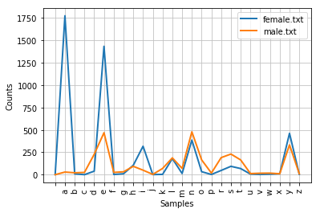

```python
cfd = nltk.ConditionalFreqDist((fileid, name[-1])
                               for fileid in names.fileids()
                               for name in names.words(fileid))
cfd.plot()
```

### 同义词, 在某种语境下具有相同词义的词语

couch / sofa

Powerful / strong

big / large

automobile / car

vomit / throw up

食盐 / 氯化钠

synset/“同义词集”:意义相同的词的集合

```python
from nltk.corpus import wordnet as wn
wn.synsets('motorcar')
```

```
[Synset('car.n.01')]
```

```python
wn.synset('car.n.01').lemma_names()
```

```
['car', 'auto', 'automobile', 'machine', 'motorcar']
```

```python
wn.synset('car.n.01').definition()
```

```
'a motor vehicle with four wheels; usually propelled by an internal combustion engine'
```

```python
wn.synset('car.n.01').examples()
```

```
['he needs a car to get to work']
```

```python
wn.synset('car.n.01').lemmas()
```

```
[Lemma('car.n.01.car'),
 Lemma('car.n.01.auto'),
 Lemma('car.n.01.automobile'),
 Lemma('car.n.01.machine'),
 Lemma('car.n.01.motorcar')]
```

```python
wn.lemma('car.n.01.automobile')
```

```
Lemma('car.n.01.automobile')
```

```python
wn.lemma('car.n.01.automobile').name()
```

```
'automobile'
```

```python
wn.synsets('car')
```

```
[Synset('car.n.01'),
 Synset('car.n.02'),
 Synset('car.n.03'),
 Synset('car.n.04'),
 Synset('cable_car.n.01')]
```

```python
wn.synsets('bank')
```

```
[Synset('bank.n.01'),
 Synset('depository_financial_institution.n.01'),
 Synset('bank.n.03'),
 Synset('bank.n.04'),
 Synset('bank.n.05'),
 Synset('bank.n.06'),
 Synset('bank.n.07'),
 Synset('savings_bank.n.02'),
 Synset('bank.n.09'),
 Synset('bank.n.10'),
 Synset('bank.v.01'),
 Synset('bank.v.02'),
 Synset('bank.v.03'),
 Synset('bank.v.04'),
 Synset('bank.v.05'),
 Synset('deposit.v.02'),
 Synset('bank.v.07'),
 Synset('trust.v.01')]
```

反义词

具有相反词义的一对词语

```python
wn.lemma('supply.n.02.supply').antonyms()
```

```
[Lemma('demand.n.02.demand')]
```

```python
wn.lemma('rush.v.01.rush').antonyms()
```

```
[Lemma('linger.v.04.linger')]
```

```python
wn.lemma('horizontal.a.01.horizontal').antonyms()
```

```
[Lemma('inclined.a.02.inclined'), Lemma('vertical.a.01.vertical')]
```

**上位词与下位词**

一个词义是另一个词义的下位词(hyponym),如果第一个词义更具体，表现为另一个词义的子类

car is a hyponym of vehicle

mango is a hyponym of fruit

同样可定义上位词(hypernym)

vehicle is a hypernym of car

fruit is a hypernym of mango

```python
motorcar = wn.synset('car.n.01')
types_of_motorcar = motorcar.hyponyms()
types_of_motorcar[0]
```

```
Synset('ambulance.n.01')
```

```python
sorted(lemma.name() for synset in types_of_motorcar for lemma in synset.lemmas())
```

```
['Model_T',
 'S.U.V.',
 'SUV',
 'Stanley_Steamer',
 'ambulance',
 'beach_waggon',
 'beach_wagon',
 'bus',
 'cab',
 'compact',
 'compact_car',
 'convertible',
 'coupe',
 'cruiser',
 'electric',
 'electric_automobile',
 'electric_car',
 'estate_car',
 'gas_guzzler',
 'hack',
 'hardtop',
 'hatchback',
 'heap',
 'horseless_carriage',
 'hot-rod',
 'hot_rod',
 'jalopy',
 'jeep',
 'landrover',
 'limo',
 'limousine',
 'loaner',
 'minicar',
 'minivan',
 'pace_car',
 'patrol_car',
 'phaeton',
 'police_car',
 'police_cruiser',
 'prowl_car',
```

[output cut: 11 more lines]

```
 'sports_car',
 'squad_car',
 'station_waggon',
 'station_wagon',
 'stock_car',
 'subcompact',
 'subcompact_car',
 'taxi',
 'taxicab',
 'tourer',
 'touring_car',
 'two-seater',
 'used-car',
 'waggon',
 'wagon']
```

```python
motorcar.hypernyms()
```

```
[Synset('motor_vehicle.n.01')]
```

```python
paths = motorcar.hypernym_paths()
len(paths)
```

```
2
```

```python
[synset.name() for synset in paths[0]]
```

```
['entity.n.01',
 'physical_entity.n.01',
 'object.n.01',
 'whole.n.02',
 'artifact.n.01',
 'instrumentality.n.03',
 'container.n.01',
 'wheeled_vehicle.n.01',
 'self-propelled_vehicle.n.01',
 'motor_vehicle.n.01',
 'car.n.01']
```

层次结构图

[figure not shown]

整体和部分的关系

```python
wn.synset('tree.n.01').part_meronyms()
```

```
[Synset('burl.n.02'),
 Synset('crown.n.07'),
 Synset('limb.n.02'),
 Synset('stump.n.01'),
 Synset('trunk.n.01')]
```

```python
wn.synset('tree.n.01').substance_meronyms()
```

```
[Synset('heartwood.n.01'), Synset('sapwood.n.01')]
```

```python
wn.synset('tree.n.01').member_holonyms()
```

```
[Synset('forest.n.01')]
```

蕴涵关系

```python
wn.synset('walk.v.01').entailments()
```

```
[Synset('step.v.01')]
```

```python
wn.synset('eat.v.01').entailments()
```

```
[Synset('chew.v.01'), Synset('swallow.v.01')]
```

**语义相似度**

根据在概念层次网中的路径定义语义相似度

如果两个同义词集共用一个非常具体的上位词，它们一定有密切的联系

寻找公共上位词

```python
right = wn.synset('right_whale.n.01')
orca = wn.synset('orca.n.01')
minke = wn.synset('minke_whale.n.01')
tortoise = wn.synset('tortoise.n.01')
novel = wn.synset('novel.n.01')
right.lowest_common_hypernyms(minke)
```

```
[Synset('baleen_whale.n.01')]
```

```python
right.lowest_common_hypernyms(orca)
```

```
[Synset('whale.n.02')]
```

```python
right.path_similarity(orca)
```

```
0.16666666666666666
```